# wsites_CWork

Nsenam Udoh - School of Computing, RGU

```r
writeLines('PATH="${RTOOLS40_HOME}\\usr\\bin;${PATH}"', con = "~/.Renviron")
```

```r
Sys.which("make")
```

```
##                               make
## "C:\\rtools40\\usr\\bin\\make.exe"
```

```r
library(devtools)
 find_rtools()
```

```
## [1] TRUE
```

# Setting Working Directory

```r
setwd("C:/Users/nsena/OneDrive/Documents/MSC_DS_RGU/CMM507_prof_dev_&_res_skills/slides/Assessment_information/indiv_coursework")
```

# installing ggplot2

```r
library(here)
```

```r
library(ggplot2)
```

# Loading the wsites

```r
wsites<-read.csv("wsites.csv")
```

# Displaying Structure of dataset

```r
str(wsites)
```

```
## 'data.frame':    190 obs. of  11 variables:
##  $ URL                      : chr  "M1_2" "M0_105" "M0_178" "M0_98" ...
##  $ URL_LENGTH               : int  45 50 69 49 48 38 21 43 49 58 ...
##  $ NUMBER_SPECIAL_CHARACTERS: int  10 13 13 13 11 11 7 11 12 13 ...
##  $ CHARSET                  : chr  "ISO-8859-1" "UTF-8" "UTF-8" "UTF-8" ...
##  $ SERVER                   : chr  "Apache" "Apache" "Apache" "Apache" ...
##  $ CONTENT_LENGTH           : int  NA NA 194 NA 640 661 686 673 4877 5962 ...
##  $ WHOIS_COUNTRY            : chr  "None" "CZ" "US" "CZ" ...
##  $ REMOTE_IPS               : int  2 1 4 2 4 5 2 5 2 2 ...
##  $ APP_BYTES                : int  531 3386 903 3571 2912 2813 603 2188 811 1692 ...
##  $ APP_PACKETS              : int  6 51 14 52 31 30 8 24 10 14 ...
##  $ Type                     : chr  "MALICIOUS" "MALICIOUS" "MALICIOUS" "MALICIOUS" ...
```

# SECTION 1

# Question 1

Plot showing the distribution of values for REMOTE_IPS

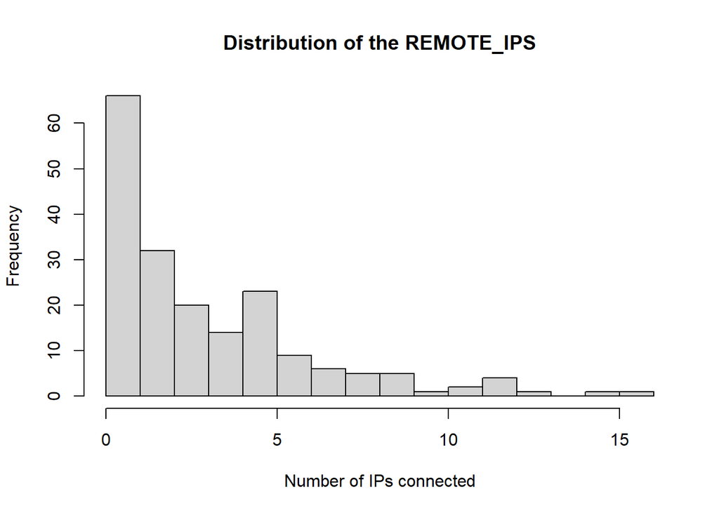

```r
hist(wsites$REMOTE_IPS, xlab = "Number of IPs connected",
main = "Distribution of the REMOTE_IPS", breaks = 20)
```

## It doesn’t show a normal distribution as the distribution is skewed

Getting the most frequent value

```r
getmode <- function(s) {
   uniqs <- unique(s)
   uniqs[which.max(tabulate(match(s, uniqs)))]
}
charv <- c(wsites$REMOTE_IPS)
result <- getmode(charv)
print(result)
```

```
## [1] 0
```

## The most frequent value is 0 and the second most frequent value is 1

# Question 2

Boxplot of URL_LENGTH by Type of website.

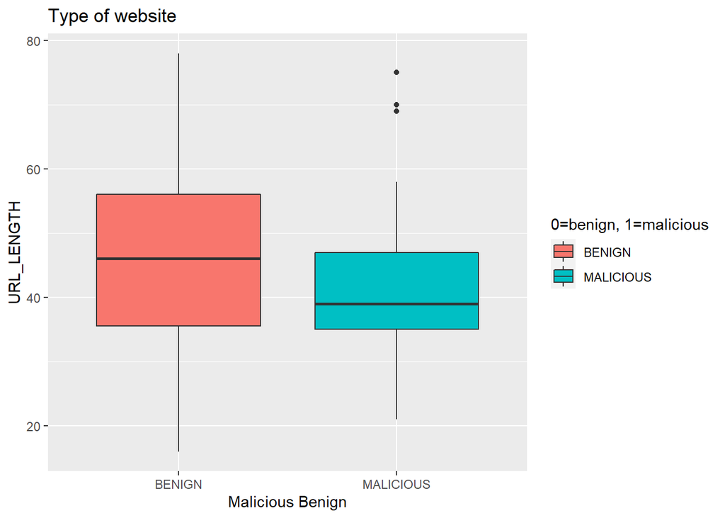

```r
ggplot(wsites, aes(Type,URL_LENGTH, fill = Type)) + geom_boxplot() +
ggtitle("Type of website") + xlab("Malicious Benign") +
labs( fill = "0=benign, 1=malicious")
```

Boxplot of URL_LENGTH by Type of website showing the outliers

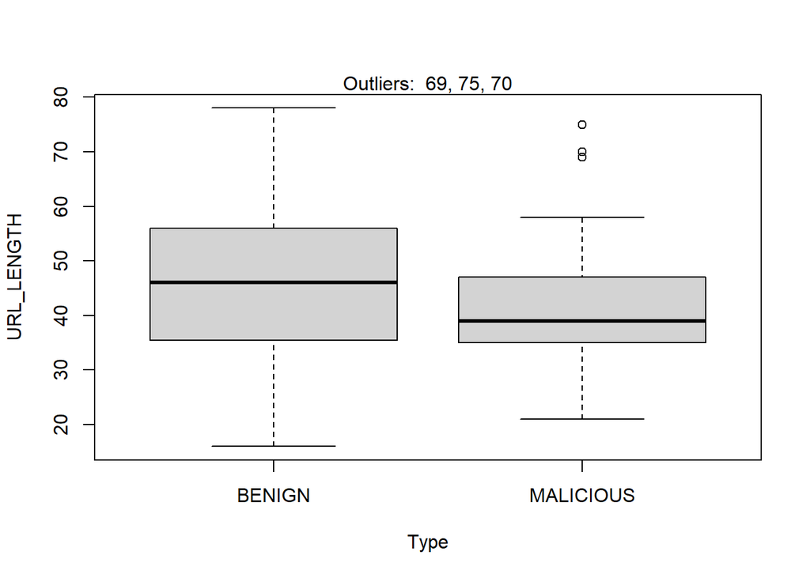

```r
out <- boxplot(URL_LENGTH ~ Type, data = wsites)$out
mtext(paste("Outliers: ", paste(out, collapse = ", ")))
```

## The malicious website has three outliers for the URL_LENGTH which are 69, 70 & 75

Finding the approximate value of the 26th highest value for each Type

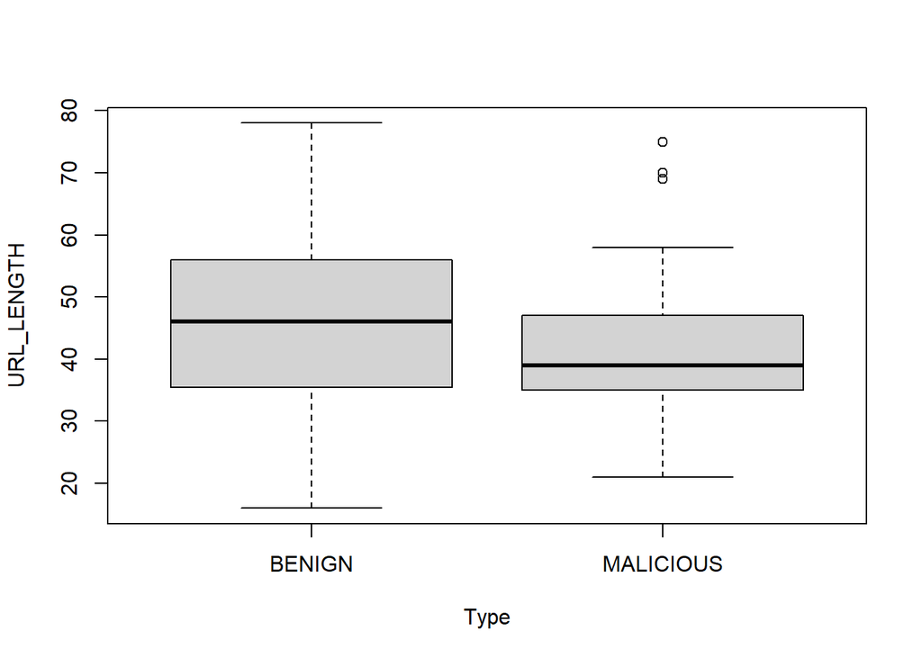

```r
res <- boxplot(URL_LENGTH ~ Type, data=wsites)
```

```r
res$stats[4,]
```

```
## [1] 56 47
```

# The approximate value of the 26th highest value for each Type will be the 4th quartile which is 75 since 75 is 26 values down from 100 which is the maximum. For the benign = 56, Malicious = 47 baring the URL_LENGTH outliers of the malicious

# Question 3

Generating scatterplot of number of app packets

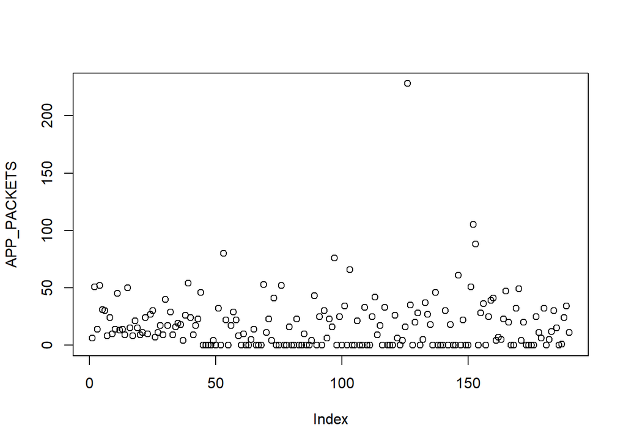

```r
attach(wsites)
plot(APP_PACKETS)
```

# The APP_Packets have their numbers mostly between 0 and 50. There is a very awkward outlier of 228 right at the very top

# Question 4

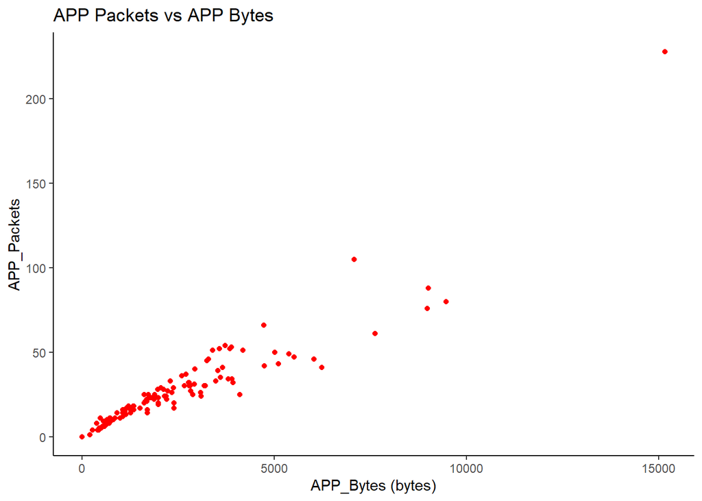

```r
p <- ggplot(wsites,aes(x=APP_BYTES,y=APP_PACKETS))
p <- p + geom_point(colour="red")
p <- p + labs(title = "APP Packets vs APP Bytes",
   x="APP_Bytes (bytes)", y = "APP_Packets")
p <- p + theme_classic()
p
```

# The variables have a strong linear correlation and the graph looks reasonably linear